# FAA Incidents data clean-up

Virgilio Salcedo Polo

Mayo 2026

## Load packages

```r
if(!require(tidyverse)){install.packages("tidyverse")}; library("tidyverse")
if(!require(lubridate)){install.packages("lubridate")}; library("lubridate")
if(!require(janitor)){install.packages("janitor")}; library("janitor")
```

```r
if(!require(stringr)){install.packages("stringr")}; library("stringr")
if(!require(readr)){install.packages("readr")}; library("readr")
if(!require(ggplot2)){install.packages("ggplot2")}; library("ggplot2")
if(!require(scales)){install.packages("scales")}; library("scales")
```

Cargamos los datos

```r
df_faa_raw=read.csv("../data_raw/faa_incidents_data.csv")
```

# Exploración inicial

```r
print ("Vistazo general")
```

```
## [1] "Vistazo general"
```

```r
glimpse(df_faa_raw)
```

```
## Rows: 100,000
## Columns: 27
## $ AIDS.Report.Number               <chr> "19780101000019I", "19780101000029I",…
## $ Local.Event.Date                 <chr> "01-JAN-78", "01-JAN-78", "01-JAN-78"…
## $ Event.City                       <chr> "WAHPETON", "FAIRBANKS", "BRUNSWICK",…
## $ Event.State                      <chr> "ND", "AK", "GA", "CA", "OR", "HI", "…
## $ Event.Airport                    <chr> "BRECKENRIDGE", "FAIRBANKS INTL", "JE…
## $ Event.Type                       <chr> "INCIDENT", "INCIDENT", "INCIDENT", "…
## $ Aircraft.Damage                  <chr> "MINOR", "MINOR", "", "MINOR", "MINOR…
## $ Flight.Phase                     <chr> "ROLL-OUT (FIXED WING)", "ROLL-OUT (F…
## $ Aircraft.Make                    <chr> "CESSNA", "PIPER", "BEECH", "CESSNA",…
## $ Aircraft.Model                   <chr> "182", "PA18", "35", "310", "172", "7…
## $ Aircraft.Series                  <chr> "UNDESIGNATED SERIES", "150", "B35", …
## $ Operator                         <chr> "", "", "", "", "", "PAN AMERICAN WOR…
## $ Primary.Flight.Type              <chr> "PERSONAL", "PERSONAL", "PERSONAL", "…
## $ Flight.Conduct.Code              <chr> "GENERAL OPERATING RULES", "GENERAL O…
## $ Flight.Plan.Filed.Code           <chr> "NONE", "VISUAL FLIGHT RULES", "NONE"…
## $ Aircraft.Registration.Nbr        <chr> "2691Q", "4073E", "7929D", "2250F", "…
## $ Total.Fatalities                 <int> 0, 0, 0, 0, 0, 0, 0, 0, 0, 0, 0, 0, 0…
## $ Total.Injuries                   <int> 0, 0, 0, 0, 0, 0, 0, 0, 0, 0, 0, 0, 0…
## $ Aircraft.Engine.Make             <chr> "", "", "", "", "", "", "", "", "", "…
## $ Aircraft.Engine.Model            <chr> "", "", "", "", "", "", "", "", "", "…
## $ Engine.Group.Code                <chr> "", "", "", "", "", "", "", "", "", "…
## $ Nbr.of.Engines                   <int> 1, 1, 1, 2, 1, NA, 2, 2, 1, 1, 1, 2, …
## $ PIC.Certificate.Type             <chr> "PRIVATE PILOT", "STUDENT", "PRIVATE …
## $ PIC.Flight.Time.Total.Hrs        <int> 245, 200, NA, 2000, 300, NA, NA, 2700…
## $ PIC.Flight.Time.Total.Make.Model <int> 136, 2, 0, 400, 130, 0, 0, 75, 430, 4…
## $ X.                               <int> 0, 0, 0, 0, 0, 0, 0, 0, 0, 0, 0, 0, 0…
## $ X..1                             <int> 0, 0, 0, 0, 0, 0, 0, 0, 0, 0, 0, 0, 0…
```

```r
print("Fatalities")
```

```
## [1] "Fatalities"
```

```r
summary(df_faa_raw$total_fatalities)
```

```
## Length  Class   Mode
##      0   NULL   NULL
```

# Realizamos la limpieza

- Las columnas x y x_1 no solo están en blanco sino que no aparecen en la descripción por lo que serán eliminadas.
- Convertimos vacios a NA.
- Convertimos la fecha a formato date y la separamos en año y mes.

```r
df_faa_clean <- df_faa_raw %>%

  clean_names() %>%

  select(-x, -x_1) %>%

  mutate(
    across(
      where(is.character),
      ~ na_if(str_trim(.x), "")
      )
    ) %>%

  mutate(
    local_event_date = dmy(local_event_date)
    ) %>%

  mutate(
    year = year(local_event_date),
    month = month(local_event_date, label = TRUE)
    )
```

```r
df_faa_clean <- df_faa_clean %>%
  mutate(
    fatal_event = total_fatalities > 0,

    injury_event = total_injuries > 0,

    severity_level = case_when(
      total_fatalities > 0 ~ "Fatal",
      total_injuries > 0 ~ "Con lesiones",
      TRUE ~ "Sin lesiones" ),

    damage_level = case_when(
      aircraft_damage %in% c("DESTROYED") ~ "Destruida",
      aircraft_damage %in% c("SUBSTANTIAL") ~ "Daño sustancial",
      aircraft_damage %in% c("MINOR") ~ "Daño menor",
      aircraft_damage %in% c("NONE") ~ "Sin daños",
      aircraft_damage %in% c("UNKNOWN") ~ "No reportado"),

    pic_experience_level = case_when(
      pic_flight_time_total_hrs < 370 ~ "Muy baja",
      pic_flight_time_total_hrs >= 370 & pic_flight_time_total_hrs < 1500 ~ "Media",
      pic_flight_time_total_hrs >= 1500 & pic_flight_time_total_hrs < 5000 ~ "Alta",
      pic_flight_time_total_hrs >= 5000 ~ "Muy alta", TRUE ~ NA_character_
      ),
    pic_experience_level_make_model = case_when(
      pic_flight_time_total_make_model < 150 ~ "Muy baja",
      pic_flight_time_total_make_model >= 150 & pic_flight_time_total_make_model < 700 ~ "Media",
      pic_flight_time_total_make_model >= 700 & pic_flight_time_total_make_model < 1500 ~ "Alta",
      pic_flight_time_total_make_model >= 1500 ~ "Muy alta", TRUE ~ NA_character_
      )
    )
```

Comprobamos la distribución de NAs

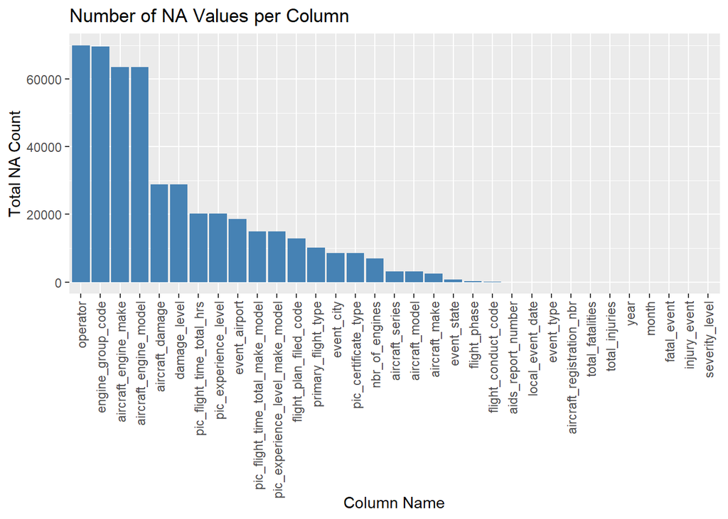

```r
na_counts_dplyr <- df_faa_clean %>%
  summarize(across(everything(), ~sum(is.na(.))))

na_counts_dplyr_tibble <- na_counts_dplyr %>%
  pivot_longer(everything(), names_to = "Column", values_to = "NA_Count") %>%
  arrange(desc(NA_Count))

na_counts_dplyr_tibble <- na_counts_dplyr_tibble %>%
  mutate(Column = factor(Column, levels = Column))

na_counts_dplyr_tibble %>%
  ggplot(aes(x = Column, y = NA_Count)) +
  geom_bar(stat = "identity", fill = "steelblue") +
  theme(axis.text.x = element_text(angle = 90, vjust = 0.5, hjust = 1)) +  # Rotate x-labels
  labs(title = "Number of NA Values per Column",
       x = "Column Name", y = "Total NA Count")
```

Necesitamos conocer algún dato sobre donde ha ocurrido el evento por lo que, al menos una de las variables relativas a la localización debe ser distinta de NA.

```r
df_faa_clean %>%
  summarise(
    nas_loc = sum(is.na(event_city) & is.na(event_state) & is.na(event_airport)),
    porcentaje = mean(is.na(event_city) & is.na(event_state) & is.na(event_airport)) * 100
  )
```

```
##   nas_loc porcentaje
## 1     408      0.408
```

Necesitamos también conocer algún dato sobre la aeronave por lo que, procedemos igual que en el caso anterior.

```r
df_faa_clean %>%
  summarise(
    nas_loc = sum(is.na(aircraft_make) & is.na(aircraft_model) & is.na(aircraft_series)),
    porcentaje = mean(is.na(aircraft_make) & is.na(aircraft_model) & is.na(aircraft_series)) * 100
  )
```

```
##   nas_loc porcentaje
## 1    2559      2.559
```

Por último, comprobamos si existen casos donde desconocemos todos los datos relativos al motor.

```r
df_faa_clean %>%
  summarise(
    nas_loc = sum(is.na(aircraft_engine_make) & is.na(aircraft_engine_model) & is.na(engine_group_code)),
    porcentaje = mean(is.na(aircraft_engine_make) & is.na(aircraft_engine_model) & is.na(engine_group_code)) * 100
  )
```

```
##   nas_loc porcentaje
## 1   63569     63.569
```

El porcentaje de observaciones en las que no conocemos ningún dato de la localización es del 0.408. Es lo suficientemente bajo como para poder eliminar dichas observaciones.  
En cuanto a los datos sobre la aeronave, los casos en los que desconocemos todos los datos son el 2.5%. Por lo que también vamos a eliminar estos datos.  
Por último, los casos donde no conocemos ningun dato sobre el motor son más del 63% por lo que no se eliminarán.

```r
df_faa_clean <- df_faa_clean %>%
  filter(!(is.na(event_city) & is.na(event_state) & is.na(event_airport)))

df_faa_clean <- df_faa_clean %>%
  filter(!(is.na(aircraft_make) & is.na(aircraft_model) & is.na(aircraft_series)))
```

```r
df_faa_clean <- df_faa_clean %>%
  mutate(
    phase_group = case_when(

      # -------------------------
      # GROUND
      # -------------------------
      flight_phase %in% c(
        "GROUND TAXI, OTHER AIRPLANE",
        "ENGINE RUN-UP",
        "STARTING ENGINES",
        "OTHER GROUND OPERATIONS",
        "OPERATIONS ON GROUND FROM LANDING/ROTORCRAFT",
        "IDLING ENGINES",
        "AERIAL TAXI, OTHER HELICOPTER",
        "IDLING ROTORS",
        "AERIAL TAXI TO TAKEOFF/ROTORCRAFT",
        "OPERATIONS ON GROUND TO TAKEOFF/ROTORCRAFT",
        "AERIAL TAXI FROM LANDING/ROTORCRAFT",
        "TAXI",
        "GROUND-RAMP",
        "RUN-UP AREA"
      ) ~ "GROUND",

      # -------------------------
      # TAKEOFF
      # -------------------------
      flight_phase %in% c(
        "TAKEOFF GROUND ROLL",
        "TO VERTICAL (HELICOPTER ONLY)",
        "TO RUNNING(HELICOPTER/VERTICAL TAKEOFF AND LANDING AIRCRAFT)",
        "TO ABORTED (FIXED WING)",
        "TO ABORTED (COPIER/RUN TAKE OFF)",
        "TAKEOFF-ABORT-COPTER VERTICAL",
        "TAKEOFF",
        "TAKEOFF: ROTATION"
      ) ~ "TAKEOFF",

      # -------------------------
      # INITIAL CLIMB
      # -------------------------
      flight_phase %in% c(
        "CLIMB",
        "TO INITIAL CLIMB (1ST POWER REDUCTION)",
        "TAKEOFF: DEPARTURE",
        "TAKEOFF: CLIMB OUT",
        "SIMULATED FORCED LANDING/TAKEOFF CLIMB"
      ) ~ "INITIAL_CLIMB",

      # -------------------------
      # CRUISE / EN ROUTE
      # -------------------------
      flight_phase %in% c(
        "NORMAL CRUISE",
        "CRUISE-LEVEL FLIGHT",
        "HOLDING INSTRUMENT FLIGHT RULES",
        "FORMATION FLYING"
      ) ~ "CRUISE",

      # -------------------------
      # DESCENT
      # -------------------------
      flight_phase %in% c(
        "DESCENT",
        "POWER ON DESCENT (ROTORCRAFT)",
        "AUTOROT DESCENT (ROTORCRAFT)"
      ) ~ "DESCENT",

      # -------------------------
      # APPROACH
      # -------------------------
      flight_phase %in% c(
        "INITIAL APPROACH-INSTRUMENT FLIGHT RULES",
        "FINAL APPROACH- INSTRUMENT FLIGHT RULES",
        "FINAL APPROACH",
        "IN TRAFFIC PATTERN-CIRCLING",
        "LANDING: APPROACH",
        "APPROACH",
        "SIMULATED FORCED LANDING FINAL APPROACH",
        "SIMULATED FORCED LANDING TRAFFIC PATTERN",
        "FCD/PREC LDG FROM CRUISE"
      ) ~ "APPROACH",

      # -------------------------
      # GO-AROUND / MISSED APPROACH
      # -------------------------
      flight_phase %in% c(
        "MISSED APPROACH INSTRUMENT FLIGHT RULES",
        "GO ROUND (ABORTED VISUAL FLIGHT RULES)",
        "SIMULATED FORCED LANDING GO AROUND"
      ) ~ "GO_AROUND",

      # -------------------------
      # LANDING
      # -------------------------
      flight_phase %in% c(
        "LEVEL OFF TOUCHDOWN",
        "TOUCH AND GO LANDING",
        "FORCED LANDING",
        "FORCED/PRECAUTIONARY LANDING",
        "POWER ON VERTICAL LANDING/ROTORCRAFT",
        "POWER ON RUN LANDING (ROTORCRAFT)",
        "POWER OFF VERTICAL LANDING/AUTOROTATE",
        "POWER OFF RUN LAND (AUTOROTATION)",
        "ROLL-OUT (FIXED WING)",
        "ROLL-OUT (ROTORCRAFT)",
        "LANDING",
        "LANDING: TOUCHDOWN",
        "LANDING: ROLLOUT",
        "SLOPE LANDING",
        "PINNACLE LANDING"
      ) ~ "LANDING",

      # -------------------------
      # MANEUVERING / SPECIAL OPS
      # -------------------------
      flight_phase %in% c(
        "PRACTICE TRAINING MENEUVERS",
        "LOW LEVEL OPERATIONS",
        "UNAUTHORIZED LOW LEVEL OPERATIONS",
        "HOVERING",
        "HOVER-HOLDING",
        "MANEUVER",
        "PARACHUTE JUMPING",
        "SCUD RUNNING",
        "SETTLE WITH POWER (ROTORCRAFT)",
        "SIMULATED FORCED LANDING CRUISE",
        "SIMULATED FORCED LANDING/TAKEOFF",
        "SIMULATED FORCED LANDING AUTOROTATION"
      ) ~ "MANEUVERING",

      # -------------------------
      # UNKNOWN / OTHER
      # -------------------------
      flight_phase %in% c(
        "UNKNOWN",
        "OTHER-SPECIFY"
      ) ~ "OTHER",

      is.na(flight_phase) ~ NA_character_,

      TRUE ~ "OTHER"
    )
  )
```

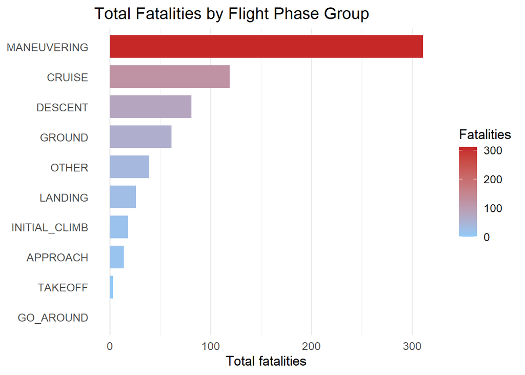

```r
phase_analysis <- df_faa_clean %>%

  group_by(phase_group) %>%

  summarise(
    total_events = n(),
    fatal_events = sum(fatal_event, na.rm = TRUE),
    total_fatalities = sum(total_fatalities, na.rm = TRUE),
    total_injuries = sum(total_injuries, na.rm = TRUE),
  ) %>%

  ungroup()

phase_analysis %>%

  filter(!is.na(phase_group)) %>%

  arrange(total_fatalities) %>%

  ggplot(
    aes(
      x = reorder(phase_group, total_fatalities),
      y = total_fatalities,
      fill = total_fatalities
    )
  ) +

  geom_col(width = 0.75) +

  coord_flip() +

  scale_fill_gradient(
    low = "#90CAF9",
    high = "#C62828"
  ) +

  scale_y_continuous(
    labels = comma_format()
  ) +

  labs(
    title = "Total Fatalities by Flight Phase Group",
    x = NULL,
    y = "Total fatalities",
    fill = "Fatalities"
  ) +

  theme_minimal(base_size = 13) +

  theme(
    legend.position = "right",
    panel.grid.major.y = element_blank()
  )
```

Guardamos los datos para usarlos en la visualización.

```r
saveRDS(df_faa_clean, "../data/faa_incidents_limpios.rds")
saveRDS(phase_analysis, "../data/faa_phase_analysis.rds")
```